# scMultiSim Tutorial

21 May 2024

# 1 Simulation Basics

scMultiSim is a simulation tool for single-cell multi-omics data. It can simulate RNA counts, ATAC-seq data, RNA velocity, and spatial locations of continuous or discrete cell populations. It can model the effects of gene regulatory networks (GRN), chromatin accessibility, and cell-cell interactions on the simulated data. In this tutorial, we will demonstrate how to use scMultiSim to simulate multi-omics data with different biological effects, including:

- Simulating true RNA counts and ATAC-seq data
- Controlling the cell population and GRN effects
- Adding technical variation and batch effect to the true counts
- Adjusting the parameters to control different biological effects

We first load the package:

```r
library("scMultiSim")
```

scMultiSim first generates the true RNA counts, and then add technical variation and batch effect to the true counts. To simulate true counts, call `sim_true_counts(options)` where `options` is a list. You can use `scmultisim_help()` to get help on the options, or like `scmulti_help("num.cells")` to get help on the options for a specific function.

```r
scmultisim_help("options")
```

## 1.1 GRN and Differentiation Tree

Before start, we define a utility function to modify a list.

```r
library(dplyr)
```

```r
list_modify <- function (curr_list, ...) {
  args <- list(...)
  for (i in names(args)) {
    curr_list[[i]] <- args[[i]]
  }
  curr_list
}
```

The minimal input to scMultiSim is a **differentiation tree**, and you can optionally provide ground truth for GRN and cell-cell interactions. The differentiation tree is an R phylo object, which can be created using e.g. `ape::read.tree()` or `ape::rtree()`. It controls the cell population structure: each node of the tree should represent a cell type, and connected nodes indicate the differentiation relationship between cell types. *scMultiSim provides this explicit control on the cell population structure while preserving all other effects (such as GRN and Cell-Cell Interactions)*, so you can generate any cell trajectory or clustering structure you want, which is especially useful for benchmarking trajectory inference and clustering methods.

If generating a continuous population, this tree specifies the cell differentiation trajectory; if generating a discrete population, the tips of this tree will be the clusters (cell types are the terminal cell states).

scMultiSim also provides three differentiation trees. `Phyla5()` and `Phyla3()` return bifurcating trees with 5 and 3 leaves respectively. `Phyla1()` returns only a single branch, which can be useful when we don’t want any specific trajectory.

```r
par(mfrow=c(1,2))
Phyla5(plotting = TRUE)
```

```
##
## Phylogenetic tree with 5 tips and 4 internal nodes.
##
## Tip labels:
##   1, 2, 3, 4, 5
##
## Rooted; includes branch lengths.
```

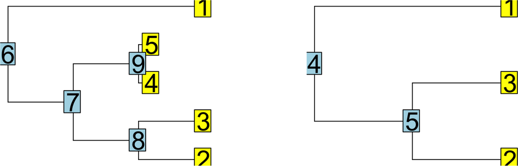

```
##
## Phylogenetic tree with 3 tips and 2 internal nodes.
##
## Tip labels:
##   1, 2, 3
##
## Rooted; includes branch lengths.
```

```r
Phyla3(plotting = TRUE)
```

```r
# It's not possible to plot Phyla1() because it only contains 1 branch connecting two nodes.
Phyla1()
```

```
##
## Phylogenetic tree with 1 tips and 1 internal nodes.
##
## Tip labels:
##   A
##
## Rooted; includes branch lengths.
```

If you only need `n` cell clusters without any specific trajectory, you can use code like below to generate a simple tree with `n` leaves.

```r
# tree with four leaves
ape::read.tree(text = "(A:1,B:1,C:1,D:1);")
```

```
##
## Phylogenetic tree with 4 tips and 1 internal nodes.
##
## Tip labels:
##   A, B, C, D
##
## Unrooted; includes branch lengths.
```

The GRN should be a data frame with 3 columns, each representing the `target`, `regulator`, and `effect`. The target and regulator should be gene names, which can be integers or strings. The effect should be a numeric value, indicating the effect of the regulator on the target.

scMultiSim provides two sample GRNs, `GRN_params_100` and `GRN_params_1139`, which contain 100 and 1139 genes respectively. Let’s load them first.

```r
data(GRN_params_100)
GRN_params <- GRN_params_100
head(GRN_params)
```

```
##   regulated.gene regulator.gene regulator.effect
## 1             16             10         1.768699
## 2             29             10         1.675360
## 3             62             10         3.723509
## 4             55             10         2.866182
## 5             81             80         4.020744
## 6             73             80         2.353371
```

## 1.2 Simulating True Counts

The number of genes is determined by the option `num.genes` or the number of genes in the GRN. If `num.genes` is not specified, the number of genes will be the number of unique genes in the GRN, plus a fraction of genes that are not regulated by any other genes. this is controlled by the option `unregulated.gene.ratio` (default is 0.1). Since our `GRN_params` contains 100 gene names, 10% more genes will be added to the simulation, and the number of genes in the simulated data will be 110. If you don’t need to simulate GRN effects, simply set `GRN = NA`.

The `cif.sigma` controls the variance of the CIFs. Usually, with `cif.sigma` = 0.1, the trajectory will be very clear, while with `cif.sigma` = 1, the trajectory will be more noisy. We use `cif.sigma` = 0.5 in this example.

We also have `do.velocity` option to use the Kinetic model to simulate RNA velocity data.

```r
options <- list(
  rand.seed = 0,
  GRN = GRN_params,
  num.cells = 1000,
  num.cifs = 50,
  cif.sigma = 0.5,
  tree = Phyla5(),
  diff.cif.fraction = 0.8,
  do.velocity = TRUE
)
```

### 1.2.1 Minimal Input

Note that the minimal input to scMultiSim is the cell population structure (differentiation tree) and number of cells. You can omit the GRN by using `GRN = NA`:

```
options <- list(
  GRN = NA
  num.cells = 1000,
  tree = Phyla5(),
)
```

### 1.2.2 Running the Simulation

Now we run the simulation and check what kind of data is in the returned result:

```r
results <- sim_true_counts(options)
```

```
## Time spent: 0.29 mins
```

```r
names(results)
```

```
##  [1] ".grn"             "unspliced_counts" ".options"         ".n"
##  [5] "region_to_gene"   "atacseq_data"     "giv"              "kinetic_params"
##  [9] "num_genes"        "velocity"         "cif"              "hge_scale"
## [13] "counts"           "cell_meta"        "atac_counts"      "region_to_tf"
## [17] "grn_params"       "cell_time"
```

The `results` contains the following important data: - `counts`: the true RNA counts (genes x cells) - `atac_counts`: the true ATAC-seq data (regions x cells) - `cell_meta`: the cell meta data, including the cell population labels

## 1.3 Visualize the Results

We can visualize the true counts and ATAC-seq data using `plot_tsne(data, labels)`:

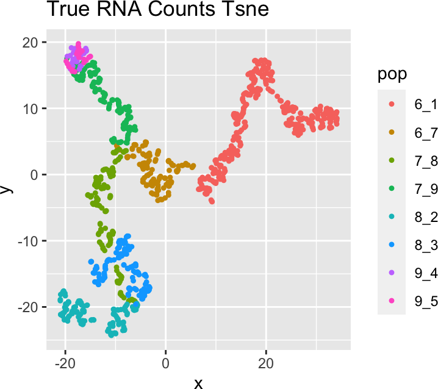

```r
plot_tsne(log2(results$counts + 1),
         results$cell_meta$pop,
         legend = 'pop', plot.name = 'True RNA Counts Tsne')
```

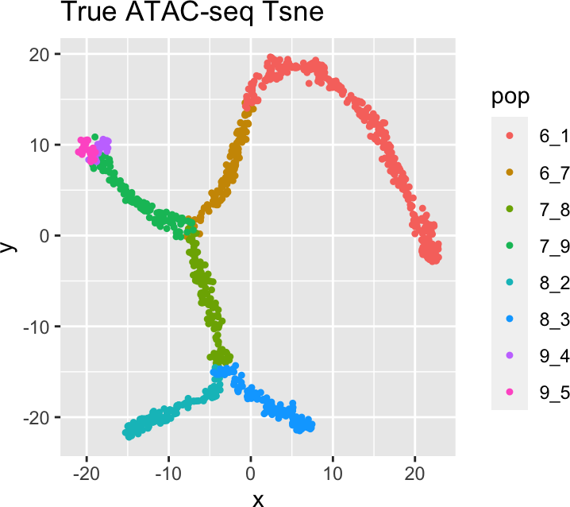

```r
plot_tsne(log2(results$atacseq_data + 1),
         results$cell_meta$pop,
         legend = 'pop', plot.name = 'True ATAC-seq Tsne')
```

Since we also have RNA velocity enabled, the `results` also contains the following data: - `velocity`: the true RNA velocity (genes x cells) - `unspliced_counts`: the true unspliced RNA counts (genes x cells)

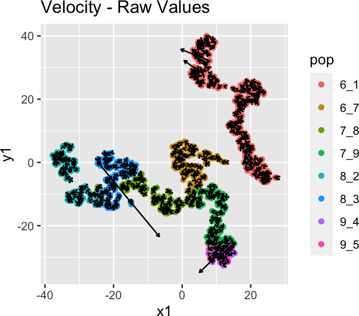

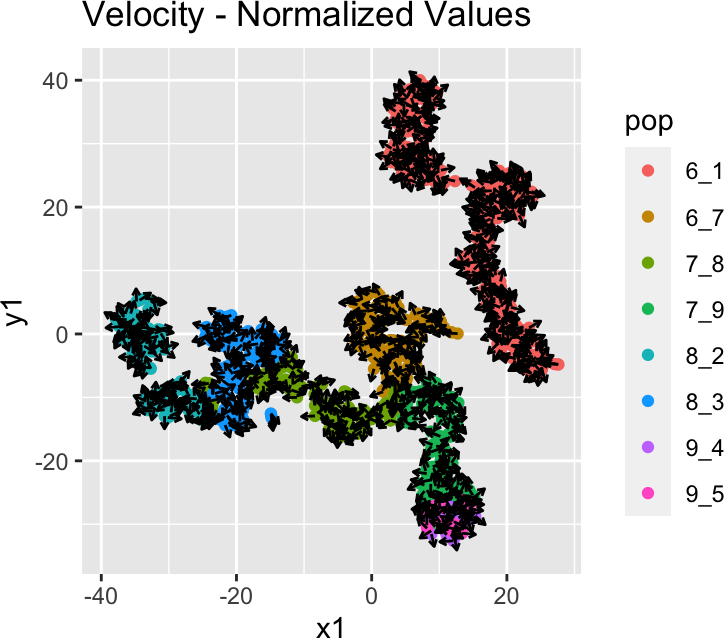

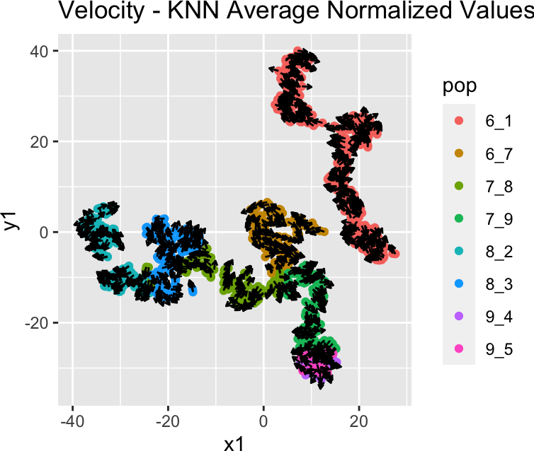

```r
plot_rna_velocity(results, arrow.length = 2)
```

We can inspect the gene-gene correlation using `plot_gene_module_cor_heatmap(results)`:

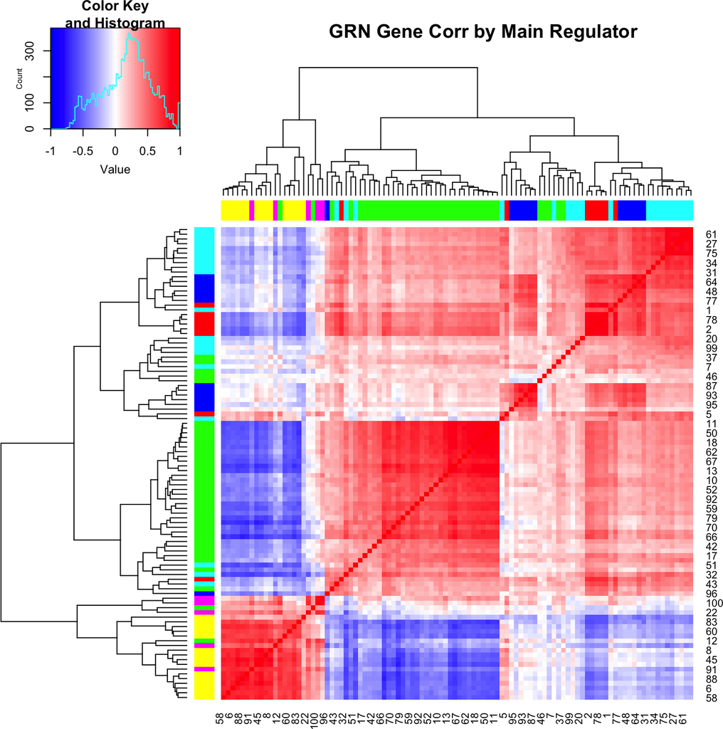

```r
plot_gene_module_cor_heatmap(results)
```

## 1.4 Adding Technical Variation

We can also add the technical variation and batch effect to the true counts:

```r
# adds `counts_obs` to `results`
add_expr_noise(results)
```

```
## Adding experimental noise...
## 50..100..150..200..250..300..350..400..450..500..550..600..650..700..750..800..850..900..950..1000..Using atac_counts
```

```
## Time spent: 0.16 mins
```

```r
# adds `counts_with_batches` to `results`
divide_batches(results, nbatch = 2)
```

```
## Adding batch effects...
```

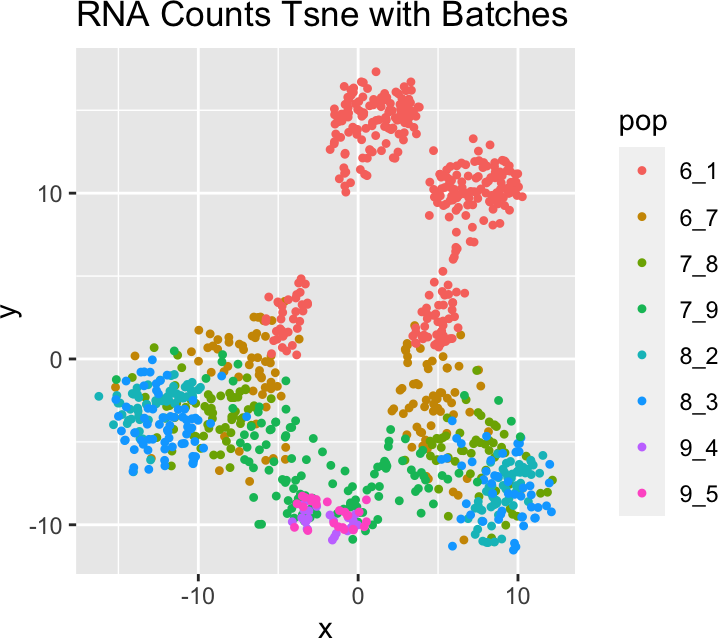

```r
plot_tsne(log2(results$counts_with_batches + 1),
         results$cell_meta$pop,
         legend = 'pop', plot.name = 'RNA Counts Tsne with Batches')
```

# 2 The Shiny App

scMultiSim provides a Shiny app to help you generate the options list and visualize the effects of different parameters. You can run the app by calling `run_shiny()`.

```r
run_shiny()
```

# 3 Adjusting Parameters

scMultiSim provides various parameters to control each type of biological effect.

## 3.2 Discrete Cell Population

We can also simulate discrete cell population by setting `discrete.cif = TRUE`. In this case, each tip of the tree will be one cell type, therefore there will be 5 clusters in the following result.

```r
options <- list(
  rand.seed = 0,
  GRN = GRN_params,
  num.cells = 1000,
  num.cifs = 50,
  tree = Phyla5(),
  diff.cif.fraction = 0.8,
  discrete.cif = TRUE
)

results <- sim_true_counts(options)
```

```
## Time spent: 0.18 mins
```

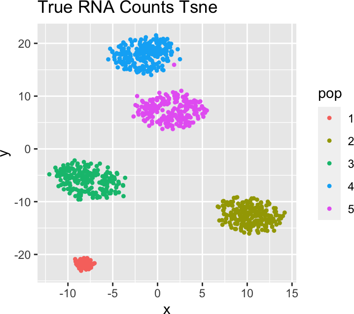

```r
plot_tsne(log2(results$counts + 1),
         results$cell_meta$pop,
         legend = 'pop', plot.name = 'True RNA Counts Tsne')
```

## 3.3 Adjusting the Effect of Cell Population

In scMultiSim, the differentiation tree provides explicit control of the cell population. The effect of the tree can be adjusted by the option `diff.cif.fraction`, which controls how many CIFs are affected by the cell population. With a larger `diff.cif.fraction`, the effect of cell population will be larger and you may see a clearer trajectory or well separated clusters. With a smaller `diff.cif.fraction`, the resulting RNA counts will be more affected by other factors, such as the GRN.

Now let’s visualize the trajectory with different `diff.cif.fraction` values:

```r
options <- list(
  rand.seed = 0,
  GRN = GRN_params,
  num.cells = 1000,
  num.cifs = 50,
  tree = Phyla5(),
  diff.cif.fraction = 0.8
)

results <- sim_true_counts(
        options %>% list_modify(diff.cif.fraction = 0.2))
```

```
## Time spent: 0.09 mins
```

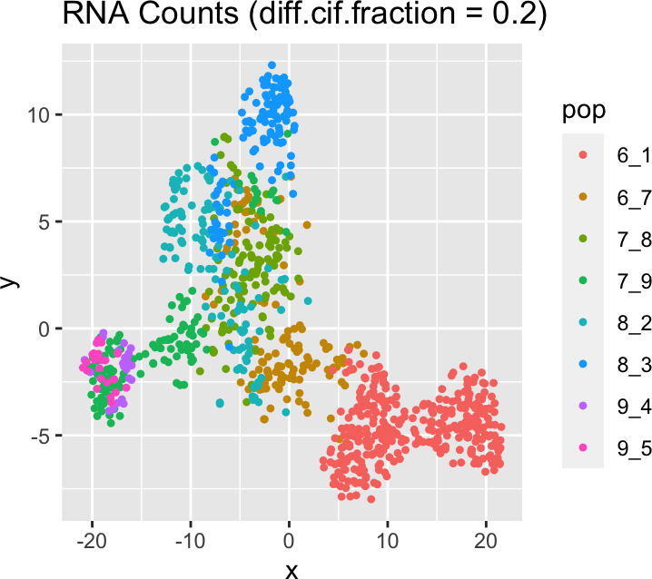

```r
plot_tsne(log2(results$counts + 1),
         results$cell_meta$pop,
         legend = 'pop', plot.name = 'RNA Counts (diff.cif.fraction = 0.2)')
```

```r
results <- sim_true_counts(
        options %>% list_modify(diff.cif.fraction = 0.8))
```

```
## Time spent: 0.09 mins
```

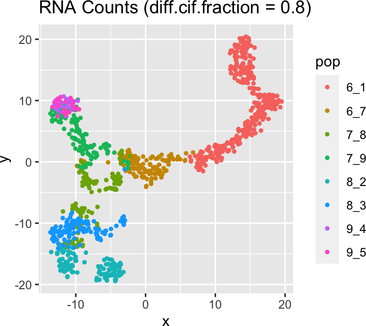

```r
plot_tsne(log2(results$counts + 1),
         results$cell_meta$pop,
         legend = 'pop', plot.name = 'RNA Counts (diff.cif.fraction = 0.8)')
```

## 3.4 Adjusting the Inherent Cell Heterogeneity

The inherent cell heterogeneity is controlled by the non-diff-CIF, which is sampled from a normal distribution with mean `cif.mean` and standard deviation `cif.sigma`. Therefore, the larger `cif.sigma` is, the larger the inherent cell heterogeneity is.

Now, let’s visualize the effect of `cif.sigma`:

```r
options <- list(
  rand.seed = 0,
  GRN = GRN_params,
  num.cells = 1000,
  num.cifs = 50,
  tree = Phyla5(),
  diff.cif.fraction = 0.8,
  cif.sigma = 0.5
)

results <- sim_true_counts(
        options %>% list_modify(cif.sigma = 0.1))
```

```
## Time spent: 0.09 mins
```

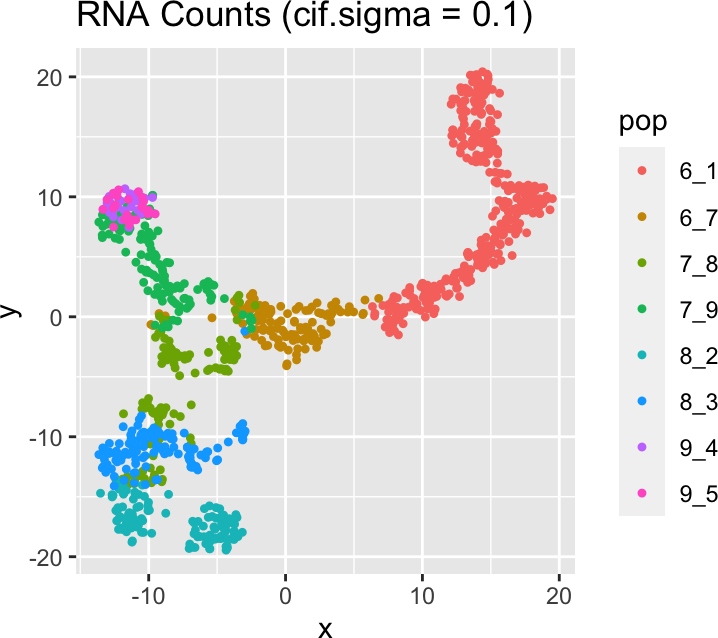

```r
plot_tsne(log2(results$counts + 1),
         results$cell_meta$pop,
         legend = 'pop', plot.name = 'RNA Counts (cif.sigma = 0.1)')
```

```r
results <- sim_true_counts(
        options %>% list_modify(cif.sigma = 1.0))
```

```
## Time spent: 0.10 mins
```

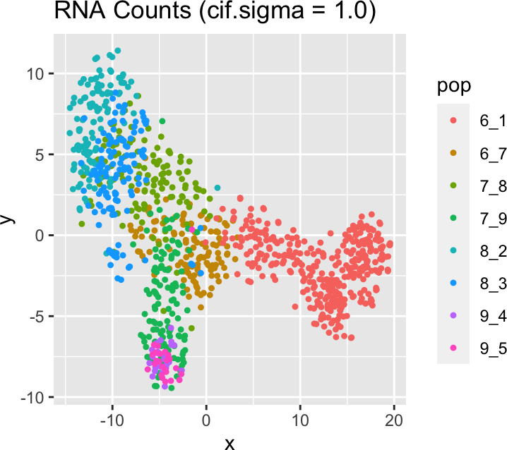

```r
plot_tsne(log2(results$counts + 1),
         results$cell_meta$pop,
         legend = 'pop', plot.name = 'RNA Counts (cif.sigma = 1.0)')
```

## 3.5 Adjusting the Intrinsic Noise

If we set `do.velocity = FALSE`, scMultiSim will simulate the RNA counts using the Beta-Poisson model, which is faster but doesn’t output RNA velocity. When using the Beta-Possion model, scMultiSim provides a `intrinsic.noise` parameter to control the intrinsic noise during the transcription process. By default, `intrinsic.noise` is set to 1, which means the true counts will be sampled from the Beta-Poisson model. If we set `intrinsic.noise` to a smaller value like 0.5, the true counts will be 0.5 * (theoretical mean) + 0.5 * (sampled from the Beta-Poisson model). *More intrinsic noise will make the encoded effects (e.g. GRN) harder to be inferred.*

```r
options <- list(
  rand.seed = 0,
  GRN = GRN_params,
  num.cells = 1000,
  num.cifs = 50,
  tree = Phyla5(),
  diff.cif.fraction = 0.8,
  intrinsic.noise = 1
)

results <- sim_true_counts(
        options %>% list_modify(intrinsic.noise = 0.5))
```

```
## Time spent: 0.10 mins
```

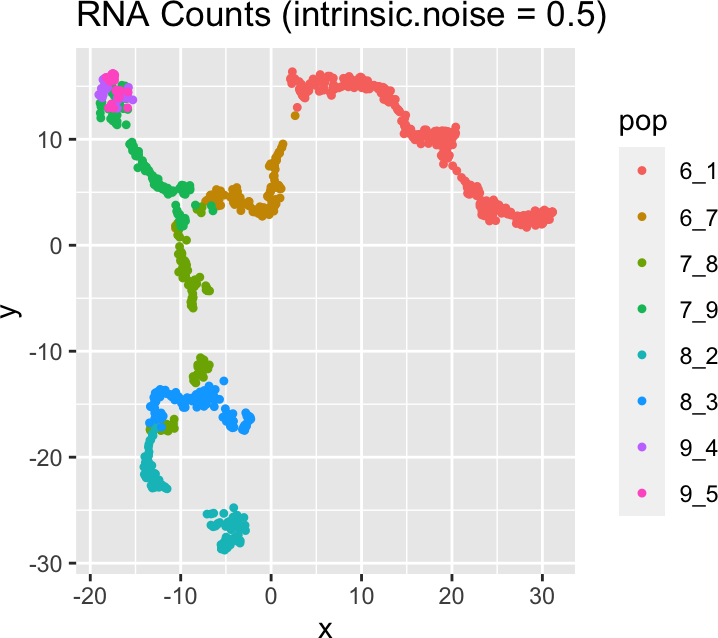

```r
plot_tsne(log2(results$counts + 1),
         results$cell_meta$pop,
         legend = 'pop', plot.name = 'RNA Counts (intrinsic.noise = 0.5)')
```

```r
results <- sim_true_counts(
        options %>% list_modify(intrinsic.noise = 1))
```

```
## Time spent: 0.09 mins
```

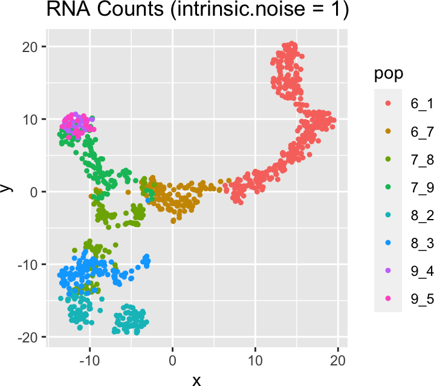

```r
plot_tsne(log2(results$counts + 1),
         results$cell_meta$pop,
         legend = 'pop', plot.name = 'RNA Counts (intrinsic.noise = 1)')
```

# 4 Simulating Dynamic GRN

First, call the following function to check the usage of dynamic GRN.

```r
scmultisim_help("dynamic.GRN")
```

```
## Dynamic GRN deletes and creates some edges in the GRN in each epoch.
## One epoch contains multiple steps, and the change is done gradually in steps.
## The specific GRN at each step will be used by one or more cells sequentially.
## When an epoch is done, another epoch will start.
##
## Available options for dynamic.GRN:
##   - seed: the random seed
##   - num.steps: number of steps in each epoch.
##   - cell.per.step: how many cells share the GRN in the same step.
##   - involved.genes: a new edge will only be created within these specified genes.
##       The default value is NA, which will use all existing genes in the GRN.
##   - num.changing.edges: if < 1, it means the portion of edges added/deleted in each epoch.
##       if >= 1, it means the number of edges added/deleted in each epoch.
##   - create.tf.edges: whether a new edge can connect two TFs in the GRN.
##   - weight.mean: the mean value of the weight for a newly created edge.
##       The default value is NA, meaning that it will use the mean value of the input GRN.
##   - weight.sd: the standard deviation of the weight for a newly created edge.
##
## See the returned list for the default values.
```

Here we use `Phyla1()` as the differentiation tree to remove the effect of the trajectory. Additionally, we can use `discrete.cif = TRUE` to simulate discrete cell population.

```r
options_ <- list(
  rand.seed = 0,
  GRN = GRN_params,
  num.cells = 1000,
  num.cifs = 50,
  tree = Phyla1(),
  diff.cif.fraction = 0.8,
  do.velocity = FALSE,
  dynamic.GRN = list(
    cell.per.step = 3,
    num.changing.edges = 5,
    weight.mean = 0,
    weight.sd = 4
  )
)

results <- sim_true_counts(options_)
```

```
## Time spent: 0.09 mins
```

`results$cell_specific_grn` is a list containing the gene effects matrix for each cell. Each row is a target and each column is a regulator. The corresponding gene names are displayed as column and row names.

```r
# GRN for cell 1 (first 10 rows)
results$cell_specific_grn[[1]][1:10,]
```

```
##           2        6       10       19 80 91
## 1  2.250484 1.824607 1.941613 4.268812  0  0
## 2  0.000000 0.000000 0.000000 0.000000  0  0
## 3  2.184071 0.000000 0.000000 0.000000  0  0
## 4  1.634807 0.000000 0.000000 0.000000  0  0
## 5  4.677883 4.301893 2.090473 4.047174  0  0
## 6  0.000000 0.000000 0.000000 0.000000  0  0
## 7  3.306285 2.673968 2.414780 3.548154  0  0
## 8  2.707510 4.653263 1.357980 1.829304  0  0
## 9  1.501430 1.970649 4.359262 3.915318  0  0
## 10 0.000000 0.000000 0.000000 0.000000  0  0
```

Since we set `cell.per.step = 3`, we expect each adjacent 3 cells share the same GRN:

```r
print(all(results$cell_specific_grn[[1]] == results$cell_specific_grn[[2]]))
```

```
## [1] TRUE
```

```r
print(all(results$cell_specific_grn[[2]] == results$cell_specific_grn[[3]]))
```

```
## [1] TRUE
```

```r
print(all(results$cell_specific_grn[[3]] == results$cell_specific_grn[[4]]))
```

```
## [1] FALSE
```